# Praca domowa 7

Aleksandra Dąbrowska

30 April 2017

# 1 Dane

```r
library(PBImisc)
library(lattice)
library(lme4)
library(ggplot2)
```

```r
attach(dementia)

head(dementia)
```

```
##   demscore  age    sex         study
## 1       53  <60   Male Poland Gdansk
## 2       36  <60   Male Poland Gdansk
## 3       74 >=60 Female Poland Gdansk
## 4       39 >=60   Male Poland Gdansk
## 5       63  <60 Female Poland Gdansk
## 6       55 >=60   Male Poland Gdansk
```

```r
summary(dementia)
```

```
##     demscore       age          sex                    study
##  Min.   :  0.0   <60 :488   Female:498   Albania          :100
##  1st Qu.: 38.0   >=60:512   Male  :502   Estonia          :100
##  Median : 50.0                           Poland Gdansk    :100
##  Mean   : 50.5                           Poland Steszew   :100
##  3rd Qu.: 63.0                           Poland Swiebodzin:100
##  Max.   :100.0                           Poland Tarnobrzeg:100
##                                          (Other)          :400
```

# 2 Interakcja wieku i płci

Rozważmy dwa modele, jeden uwzględniający interakcje między zmiennymi `age` i `sex` oraz bez tej interakcji.

```r
model_staly <- lm(demscore~age+sex, data=dementia)
model_interakcja <- lmer(demscore~age+sex + (1|study), data=dementia, REML = F)
model_bez_interakcji <- lmer(demscore~age*sex+(1|study), data=dementia,REML=F)

anova(model_interakcja,model_bez_interakcji)
```

```
## Data: dementia
## Models:
## model_interakcja: demscore ~ age + sex + (1 | study)
## model_bez_interakcji: demscore ~ age * sex + (1 | study)
##                      Df    AIC    BIC  logLik deviance  Chisq Chi Df
## model_interakcja      5 8345.8 8370.3 -4167.9   8335.8
## model_bez_interakcji  6 8347.5 8377.0 -4167.8   8335.5 0.2406      1
##                      Pr(>Chisq)
## model_interakcja
## model_bez_interakcji     0.6238
```

Jak widzimy efekt interakcji zmiennych nie wnosi wiele do modelu. W następnych krokach będziemy rozważać model bez interkacji.

# 3 Zróżnicowanie między ośrodkami

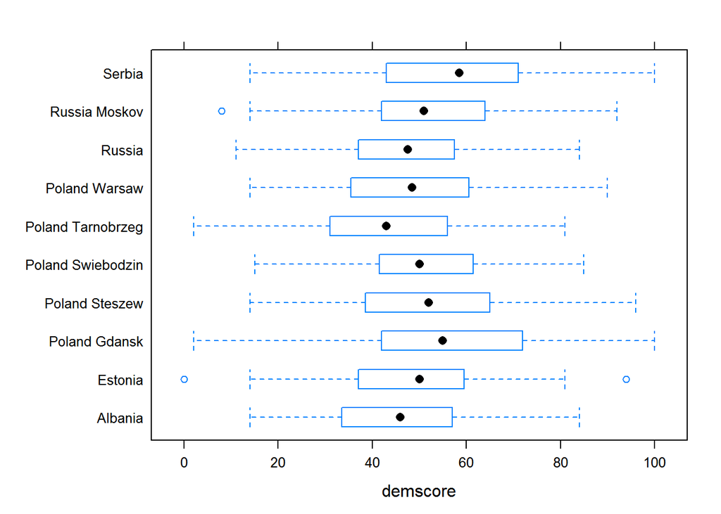

```r
bwplot(study~demscore, data=dementia)
```

Jak widzimy współczynnik `demscore` różni się między ośrodkami. Kwalifikujemy zmienną `study` jako efekt losowy, ponieważ nie mamy informacji dla wszystkich możliwych poziomów tej zmiennej.

# 4 Testy

## 4.1 Testy dla efektów stałych

### 4.1.1 ML

Porównamy modele bez i z daną cechą.

```r
model <- lmer(demscore~sex+age + (1|study), data= dementia, REML=F)
summary(model)
```

```
## Linear mixed model fit by maximum likelihood  ['lmerMod']
## Formula: demscore ~ sex + age + (1 | study)
##    Data: dementia
##
##      AIC      BIC   logLik deviance df.resid
##   8345.8   8370.3  -4167.9   8335.8      995
##
## Scaled residuals:
##      Min       1Q   Median       3Q      Max
## -2.81820 -0.68924  0.00969  0.66936  2.97174
##
## Random effects:
##  Groups   Name        Variance Std.Dev.
##  study    (Intercept)  11.42    3.379
##  Residual             239.94   15.490
## Number of obs: 1000, groups:  study, 10
##
## Fixed effects:
##             Estimate Std. Error t value
## (Intercept)  50.5862     1.3612   37.16
## sexMale     -10.6869     0.9886  -10.81
## age>=60      10.3118     0.9843   10.48
##
## Correlation of Fixed Effects:
##         (Intr) sexMal
## sexMale -0.343
## age>=60 -0.349 -0.059
```

```r
modelbezSex <- update(model,.~.-sex)
modelbezAge <- update(model,.~.-age)

anova(model, modelbezAge)
```

```
## Data: dementia
## Models:
## modelbezAge: demscore ~ sex + (1 | study)
## model: demscore ~ sex + age + (1 | study)
##             Df    AIC    BIC  logLik deviance  Chisq Chi Df Pr(>Chisq)
## modelbezAge  4 8447.9 8467.5 -4220.0   8439.9
## model        5 8345.8 8370.3 -4167.9   8335.8 104.13      1  < 2.2e-16 ***
## ---
## Signif. codes:  0 '***' 0.001 '**' 0.01 '*' 0.05 '.' 0.1 ' ' 1
```

```r
anova(model, modelbezSex)
```

```
## Data: dementia
## Models:
## modelbezSex: demscore ~ age + (1 | study)
## model: demscore ~ sex + age + (1 | study)
##             Df    AIC    BIC  logLik deviance  Chisq Chi Df Pr(>Chisq)
## modelbezSex  4 8454.3 8473.9 -4223.1   8446.3
## model        5 8345.8 8370.3 -4167.9   8335.8 110.51      1  < 2.2e-16 ***
## ---
## Signif. codes:  0 '***' 0.001 '**' 0.01 '*' 0.05 '.' 0.1 ' ' 1
```

Jak widzimy oba stałe komponenty okazują się istotne.

### 4.1.2 Test Walda

```r
#dla sex
2*pnorm(10.79,lower.tail = FALSE)
```

```
## [1] 3.837895e-27
```

```r
#dla age
2*pnorm(10.46, lower.tail = FALSE)
```

```
## [1] 1.318557e-25
```

Zatem dane efekty stałe są istotnie różne od zera.

### 4.1.3 Test permutacyjny

```r
dementia2 <- dementia
rozklad <- replicate(999, {
  dementia2$age2<- sample(dementia$age)
  model_p <- lmer(demscore ~ age2 + sex + (1 | study), data = dementia2,REML=FALSE)
  logLik(model_p)

})

(sum(rozklad>logLik(model))+1)/(1000)
```

```
## [1] 0.001
```

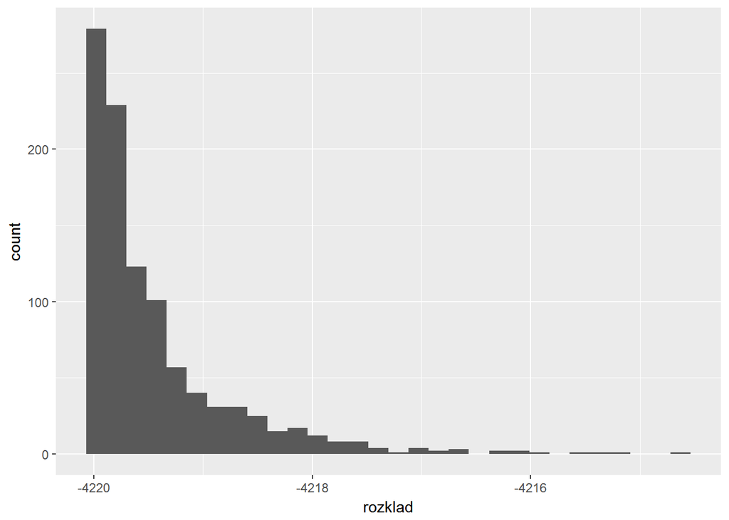

```r
rozklad <- as.data.frame(rozklad)
ggplot(rozklad, aes(rozklad))+geom_histogram()
```

```r
rozklad <- replicate(999, {
  dementia2$sex2<- sample(dementia$sex)
  model_p <- lmer(demscore ~ age + sex2 + (1 | study), data = dementia2,REML=FALSE)
  logLik(model_p)

})

(sum(rozklad>logLik(model))+1)/(1000)
```

```
## [1] 0.001
```

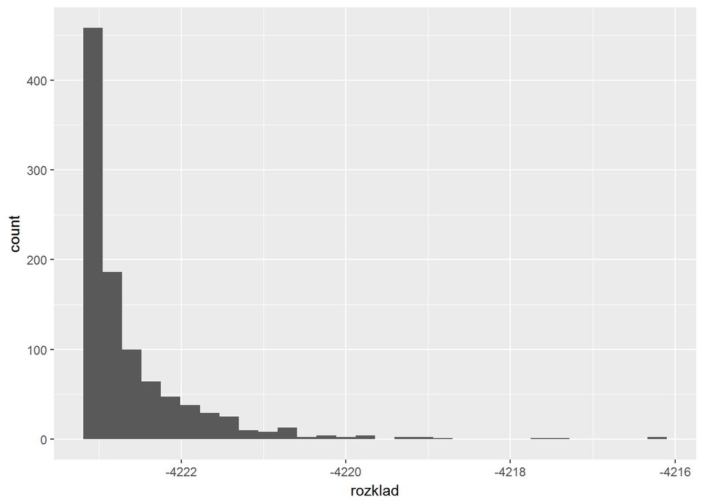

```r
rozklad <- as.data.frame(rozklad)
ggplot(rozklad, aes(rozklad))+geom_histogram()
```

Test permutacyjny także wskazuje istotność zmiennej `age` i `sex`.

## 4.2 Testy dla efektu losowego `study`

### 4.2.1 Test ilorazu wiarogodności

```r
logLikmieszany <- logLik(model)
logLikstaly <- logLik(model_staly)

(roznica <- as.numeric(logLikstaly-logLikmieszany))
```

```
## [1] -14.43517
```

```r
pchisq(-2*roznica, 1, lower.tail=FALSE)
```

```
## [1] 7.738888e-08
```

```r
pchisq(-2*roznica, 10, lower.tail=FALSE)
```

```
## [1] 0.001307703
```

Aby wykonać test LRT nie możemy użyć funkcji `anova()`, ponieważ mamy argumenty różnych klas. Zarówno gdy rozważamy rozkład chi-kwadrat z 1 jak i z 10 stopniami swobody( o tyle efektów losowych różnią się te modele) widzimy, że zmienna `study` jest istotna.

### 4.2.2 Test permutacyjny

```r
rozklad <- replicate(999, {
  dementia2$study<- sample(dementia$study)
  model_p <- lmer(demscore ~ age + sex + (1 | study), data = dementia2,REML=FALSE)
  logLik(model_p)

})

(sum(rozklad>logLik(model))+1)/(1000)
```

```
## [1] 0.001
```

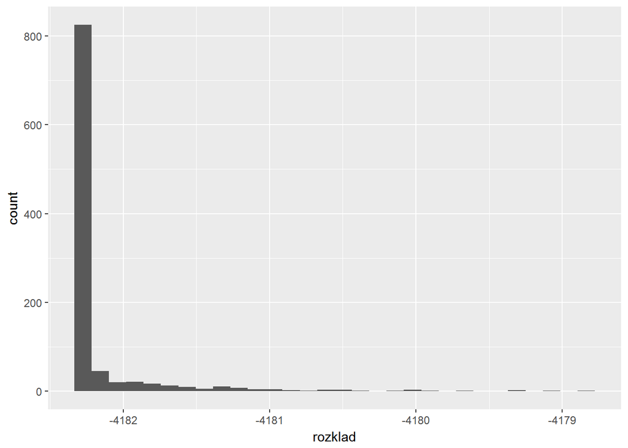

```r
rozklad <- as.data.frame(rozklad)
ggplot(rozklad, aes(rozklad))+geom_histogram()
```

Test permutacyjny także wskazuje istotność tej zmiennej.

## 4.3 Losowość w zmiennych `age` i `sex`

Na koniec porównamy modele z których usuniemy efekt płci lub wieku z efektów losowych.

```r
model_0 <-lmer(demscore~age+sex+(age+sex|study), data=dementia, REML=F)

model_1 <- lmer(demscore~age+sex+(age|study), data=dementia, REML=F)

model_2 <- lmer(demscore~age+sex+(sex|study), data=dementia, REML=F)

anova(model_0,model_1)
```

```
## Data: dementia
## Models:
## model_1: demscore ~ age + sex + (age | study)
## model_0: demscore ~ age + sex + (age + sex | study)
##         Df    AIC    BIC  logLik deviance Chisq Chi Df Pr(>Chisq)
## model_1  7 8309.0 8343.3 -4147.5   8295.0
## model_0 10 8312.7 8361.7 -4146.3   8292.7 2.305      3     0.5116
```

```r
anova(model_0,model_2)
```

```
## Data: dementia
## Models:
## model_2: demscore ~ age + sex + (sex | study)
## model_0: demscore ~ age + sex + (age + sex | study)
##         Df    AIC    BIC  logLik deviance  Chisq Chi Df Pr(>Chisq)
## model_2  7 8349.2 8383.6 -4167.6   8335.2
## model_0 10 8312.7 8361.7 -4146.3   8292.7 42.573      3  3.032e-09 ***
## ---
## Signif. codes:  0 '***' 0.001 '**' 0.01 '*' 0.05 '.' 0.1 ' ' 1
```

Jak widzimy efekt losowy płci jest niewielki, a efekt losowy wieku jest istotny.

Stąd w końcowym modelu warto rozważyć efekt losowy wieku oraz stałe wieku i płci.